# algoan slides

#### An Algorithm is a recipe to solve a problem

- There may be many algorithms for solving a particular problem.
  - Can you name one problem where we saw this?
- Since there are different solutions, not all of them are equally efficient.
  - How do we compare them?
- ifact(20) : 1.38 µs ± 3.57 ns
- rfact(20) : 3.91 µs ± 8.07 ns
- ifact(200) : 18.2 µs ± 295 ns
- rfact(200) : 47.8 µs ± 357 ns

##### ifact( ) ~3 times faster than rfact( )

- iexp(20) : 1.01 µs ± 5.36 ns
- rexp(20) : 1.28 µs ± 10.2 ns
- iexp(200): 10.9 µs ± 44.5 ns
- rexp(200): 2.25 µs ± 8.17 ns

##### Which one is faster?

#### How to compare different programs?

- Measure their execution times
  - Depends upon data
  - Depends upon the hardware (clock speed, branch prediction and pipelining)
  - Depends upon whether it is a multi-user system or a single-user system
    - context-switching and interrupt handling
    - Memory access and cache performance
  - Depends upon the programming language
    - compiler, optimiser, interpreter...
  - Depends on the time of the day :-)

#### So, what do we do?

[figure not shown]

#### We need an implementation independent way of doing this...

[figure not shown]

[figure not shown]

- Can we examine the solution and measure those aspects of the algorithm that most critically affect its execution time?
- For example, we could count the number of logical comparisons, data interchanges, or arithmetic operations.

# Analysis of Algorithms

#### Instead of analysing

### programs,

#### let's analyse

### algorithms!

#### Count the number of additions (matadd-v1)

n = 10

totalSum = 0

for i in range( n ) :

```
rowSum[i] = 0
for j in range( n ) :
    rowSum[i] = rowSum[i] + matrix[i,j]
    totalSum = totalSum + matrix[i,j]
```

- Inner loop has 2 additions, which goes n times: 2n
- Outer loop has n iterations.
- So, total number of additions: $2n \times n = 2n^2$

*Can we reduce the number of additions?*

#### Count the number of additions (matadd-v2)

n = 10

totalSum = 0

for i in range( n ) :

```
rowSum[i] = 0
for j in range( n ) :
    rowSum[i] = rowSum[i] + matrix[i,j]
totalSum = totalSum + rowSum[i]  <-- Add rowSum after inner loop is over
```

- inner loop has 1 addtion, which goes n times: n
- outer loop has n iterations: $n^2$
- outer loop has 1 addition: n
- So, total number of additions: $n^2 + n < 2n^2$

#### Compare matadd-v1 and matadd-v2

- matadd-v1 needs $2n^2$ additions
- matadd-v2 needs $n^2 + n$ additions

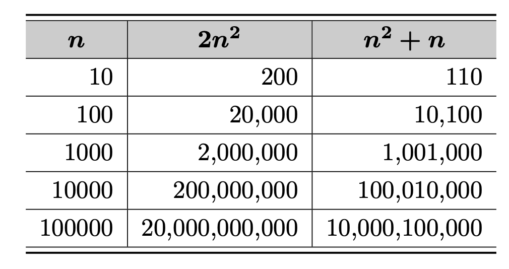

https://www.desmos.com/calculator/t4vhi0rfzm

$\log_{10} 10 = 1$

- The power of 10 which gives 10 is **1**.

$\log_{10} 100 = 2$

- The power of 10 which gives 100 is **2**.

$\log_{10} 1000 = 3$

- The power of 10 which gives 1000 is **3**.

#### Converting from one base to another

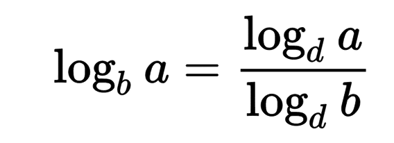

- $\log_2 10 = \frac{\log_{10} 10}{\log_{10} 2}$
- $\log_{10} 10 = 1,\; \log_{10} 2 = 0.3010$
- $\log_2 10 = \frac{1} {0.3010} = 3.322 $

#### What would we like to measure?

- We shall be interested in in the rate of growth of the time or space required to solve larger and larger instances of a problem.
- We would like to associate with a problem an integer, called the **size** of the problem, which is a measure of the *quantity of input data*.
- The time needed by an algorithm expressed as a function of the size of a problem is called the **time complexity** of the algorithm.
- The space needed by an algorithm expressed as a function of the size of a problem is called the **space complexity** of the algorithm.

#### What would we like to measure? ...

- Instead of counting the precise number of operations or steps, computer scientists are more interested in classifying an algorithm based on the **order of magnitude** as applied to execution time or space requirements.
- This classification approximates the actual number of required steps for execution or the actual storage requirements in terms of variable-sized data sets.
- The term **big-Oh**, which is derived from the expression *“on the order of,”* is used to specify an algorithm’s classification.

### What is Big-Oh?

- Assume we have a function $T(n)$ that represents the approximate number of steps required by an algorithm for an input of size $n$.
- For matadd-v2, we can write: $$T(n) = n^2 + n $$
- Now, suppose there exists a function $f(n)$ for $n\geq 0$, such that for some constant $c$, and some constant $m$, $$T(n) \leq c f(n),$$ for all values of $n \geq m$.

https://www.desmos.com/calculator/qgvssvewsn

- Suppose $f(n) = n^3$ and $T(n) = n^2 + n$.
  - $f(1) = 1,\;\; T(1) = 2$
  - $f(2) = 8,\;\; T(2) = 6$
  - $f(3) = 27,\; T(3) = 12$
- $T(n) \leq cf(n)$, for $c = 1$ and $m = 2 (n\geq m)$.
- $T(n) \leq cf(n)$, for $c = 3$ and $m = 1 (n\geq m)$.

#### What is Big-Oh?

- Such an algorithm $T(n)$ is said to have a *time-complexity* of, or executes *on the order of*, $f(n)$ relative to the number of operations it requires.
- There exists a positive integer $m$ and a constant $c$ **(constant of proportionality)** such that for all $n\geq m$, $T(n) \leq cf(n)$.
- We say $T(n)$ runs *on the order of* $f(n)$: $$ T(n) = O(f(n)) = O(n^3)$$
- The function $f(n)$ provides an **upper bound** for the running time of $T(n)$.
- The objective usually is to find a function $f(\cdot)$ that is the **lowest upper bound**.

#### Big-Oh Notation

- The objective usually is to find a function $f(\cdot)$ that is the **lowest upper bound**.
- Can we find a tighter upper bound for $T(n) = n^2 + n$
  - $f(n) = n^3$
  - $f(n) = 1000 n^2$
  - $f(n) = 3 n^2$
  - $f(n) = 2 n^2$

##### Find the $c$ and $m$ for the above upper bounds

## Growth Rate of Some Common Functions

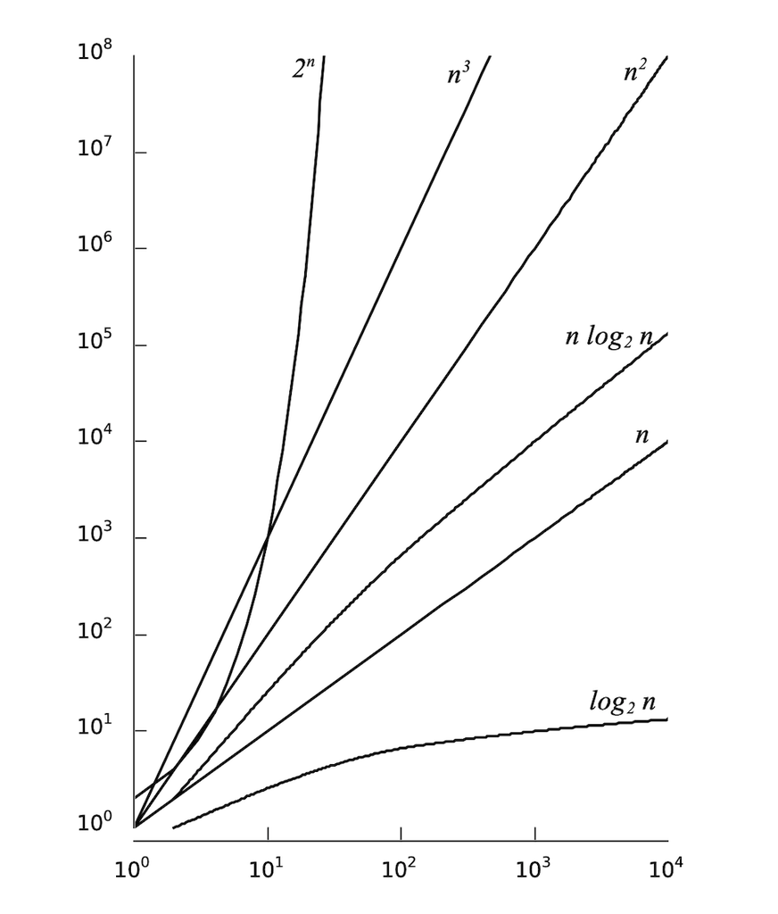

#### An example

- Suppose $T(n) = n^2 + log_2 n + 3n$
  - Which is the *dominating* (largest) term when...
    - n = 1?
    - n = 2?
    - n = 3?
    - n = 4?

#### An example...

- $T(n) = n^2 + log_2 n + 3n$
1. $n^2 + log_2 n + 3n \leq n^2 + n^2 + n^2 $
2. $n^2 + log_2 n + 3n \leq 3n^2$
- $T(n) = O(n^2)$
  - $\because T(n)\leq 3n^2, c = 3, f(n) = n^2 $
- $T(n) = 2n^2 + 15n + 500$
- Find $f(n), c, m$ such that $T(n) = O(f(n))$.

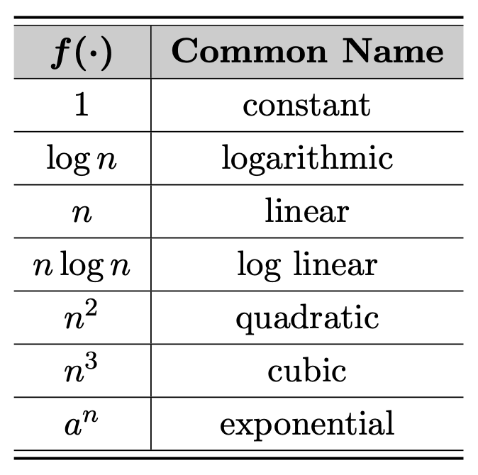

#### Constant of Proportionality

- The constant of proportionality is only crucial when two algorithms have the same $f(n)$.
- It usually makes no difference when comparing algorithms whose growth rates are of different magnitudes.
  - Suppose we have two algorithms, $L_1$ and $L_2$, with run times equal to $n^2$ and $2n$ respectively.
  - $L_1$ has a time-complexity of $O(n^2)$ with $c=1$ and $L_2$ has a time complexity of $O(n)$ with $c=2$.
  - Even though $L_1$ has a smaller constant of proportionality, $L_1$ is still slower and, in fact an order of magnitude slower, for large values of $n$.

#### Constructing T(n)

- Instead of counting the number of logical comparisons or arithmetic operations, we evaluate an algorithm by considering every operation.
- For simplicity, we assume that each basic operation or statement, at the abstract level, takes the same amount of time and, thus, each is assumed to cost constant time.

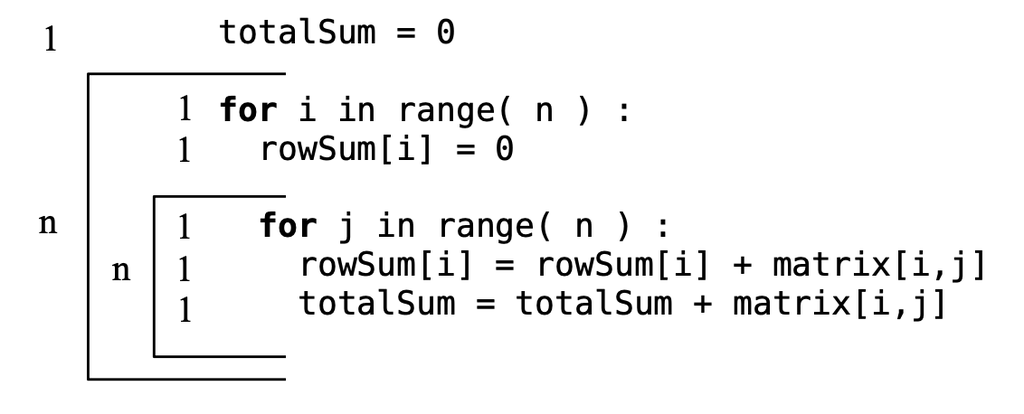

- For all practical purposes, we can ignore the first line of the algorithm.

## Pseudocode

- An algorithm expressed with all the necessary details
- Independent of the syntax of any particular programming language

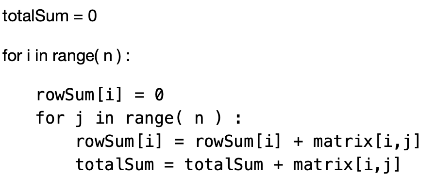

- The limiting behaviour of the compiexity as size increases is called the **asymptotic** time complexity.
- Analogous definitions can be made for **space complexity** and asymptotic space complexity.

## Why are these straight lines, btw?

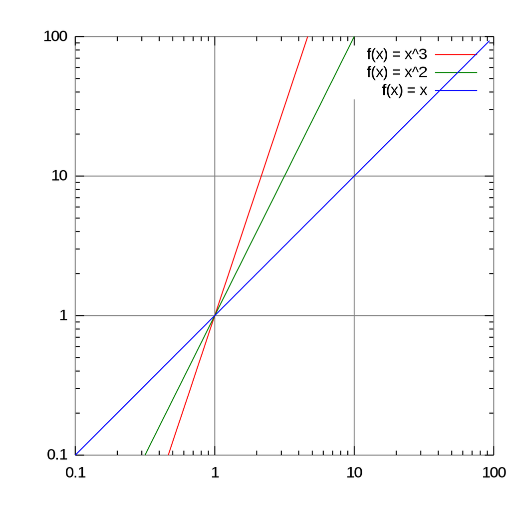

#### What is the time complexity of the following algorithm?

```
def addup( n ):

    total = 0
    for i in range( n ) :
        total += i
    return total
```

#### What is the time complexity of the following algorithm?

```
def addmore( n ):


    count = 0
    for i in range( n ) :
        for j in range( n ) :
            count += 1
    return count
```

#### What is the time complexity of the following algorithm?

```
def countit( n ):

    count = 0
    i=n
    while i >= 1 :
        count += 1
        i = i // 2
    return count
```

```python
def countit( n ):
    count = 0
    i=n
    while i >= 1 :
        print(i)
        count += 1
        i = i // 2
    return count
```

```python
countit(18)
```

[output not shown]

#### The number of iterations in countit (n) is:

$\lfloor {\log_2 n}\rfloor + 1 $

```python
def callcountit(n):
    count = 0
    for i in range(n):
        count += countit(n)
    return count
```

```python
callcountit(4)
```

[output not shown]

#### Various running times

- Some algorithms' times **differ** even for inputs of the **same** size

$ \longrightarrow $

##### Write a function insatind(array,position,element) to insert an element into an array at the specified index (position).

- - Suppose arr = [1,4,3,2]
    - insatind(arr,3,6) should return [1,4,6,3,2]

$\longrightarrow$

##### Write a function srch(array,element) that searches the array for the element and returns the index (position) in the array if the element is found, and -1 otherwise.

- - Suppose arr = [1,4,3,2]
    - srch(arr,3) should return 3
    - srch(arr,6) should return -1

### Various running times...

- Some algorithms' times *differ* even for inputs of the *same* size
  - In searching in an *unsorted* array, an element at the beginning is found faster.
  - Adding an element at the beginning of an array is slower than at the end.
- Such algorithms can be evaluated for their **best, worst, and average cases (and therefore, times)**.

#### srch(array,element)

- best case: when element is first in the array
- worst case: when element is not in the array
- average case?
- Generally, we are interested in the **worst case** time-complexity.

### Finding the time-complexity of a recursive algorithm

```
def fact1(n):
    if n == 1:
        return 1
    if n == 0:
        return 1
    return(n*fact1(n-1))
```

### Recurrence Equation (or Recurrence Relation)

```
def fact1(n):
    if n == 1:
        return 1
    if n == 0:
        return 1
    return(n*fact1(n-1))
```

$$ T(n) = \left\{ \begin{array}\\ 1 & \mbox{if } \ n = 1 \\ 1+T(n-1) & \mbox{if } \ n > 1 \\ \end{array} \right.$$

$$ T(n) = \left\{ \begin{array}\\ 1 & \mbox{if } \ n = 1 \\ 1+T(n-1) & \mbox{if } \ n > 1 \\ \end{array} \right.$$

$T(n) = 1 + (1 + T(n - 2))$

$T(n) = 2 + T(n - 2)$

$T(n) = 2 + (1 + T(n - 3))$

$T(n) = 3 + T(n - 3)$

$$ T(n) = \left\{ \begin{array}\\ 1 & \mbox{if } \ n = 1 \\ 1+T(n-1) & \mbox{if } \ n > 1 \\ \end{array} \right.$$

$T(n) = 1 + (1 + T(n - 2))$

$T(n) = 2 + T(n - 2)$

$T(n) = 2 + (1 + T(n - 3))$

$T(n) = 3 + T(n - 3)$

$T(n) = n-1 + T(n - (n-1))$

$T(n) = n-1 + T(1)$

$T(n) = n-1 + 1$

$T(n) = O(n)$

### Recurrence Equation (or Recurrence Relation)

```
def fact1(n):
    assert n >= 0 and int(n) == n, "positive integers only, please! :-) "
    if n == 1:
        return 1
    if n == 0:
        return 1
    return(n*fact1(n-1))
```

$$ T(n) = \left\{ \begin{array}\\ c & \mbox{if } \ n = 1 \\ c+T(n-1) & \mbox{if } \ n > 1 \\ \end{array} \right.$$

$$ T(n) = \left\{ \begin{array}\\ c & \mbox{if } \ n = 1 \\ c+T(n-1) & \mbox{if } \ n > 1 \\ \end{array} \right.$$

$T(n) = c + (c + T(n - 2))$

$T(n) = 2c + T(n - 2)$

$T(n) = 2c + (c + T(n - 3)$

$$ T(n) = \left\{ \begin{array}\\ c & \mbox{if } \ n = 1 \\ c+T(n-1) & \mbox{if } \ n > 1 \\ \end{array} \right.$$

$T(n) = c + (c + T(n - 2))$

$T(n) = 2c + T(n - 2)$

$T(n) = 2c + (c + T(n - 3)$

$T(n) = 3c + T(n - 3)$

$T(n) = nc + T(n - n)$

$T(n) = nc + T(0)$

$T(n) = nc + c$

$T(n) = O(n)$

$$ T(n) = \left\{ \begin{array}\\ c & \mbox{if } \ n = 1 \\ c+T(n/2) & \mbox{if } \ n > 1 \\ \end{array} \right.$$

$$ T(n) = \left\{ \begin{array}\\ c & \mbox{if } \ n = 1 \\ c+T(n/2) & \mbox{if } \ n > 1 \\ \end{array} \right.$$

$T(n) = c + T(n/2)) \implies T(n) = c + [c + T(n/4)] \implies T(n) = 2c + T(n/4)$

$T(n) = 2c + [c + T(n/8)] \implies T(n) = 3c + T(n/8)$

$T(n) = 3c + T(n/2^3)$

$T(n) = 3c + [c + T(n/2^4)] \implies T(n) = 4c + T(n/2^4)$

$$ T(n) = \left\{ \begin{array}\\ c & \mbox{if } \ n = 1 \\ c+T(n/2) & \mbox{if } \ n > 1 \\ \end{array} \right.$$

$T(n) = c + T(n/2)) \implies T(n) = c + [c + T(n/4)] \implies T(n) = 2c + T(n/4)$

$T(n) = 2c + [c + T(n/8)] \implies T(n) = 3c + T(n/8)$

$T(n) = 3c + T(n/2^3)$

$T(n) = 3c + [c + T(n/2^4)] \implies T(n) = 4c + T(n/2^4)$

##### When will we reach T(1) ?

##### Suppose $2^k = n,$

$T(n) = kc + T(n/2^k)$

$T(n) = (k+1)c$

##### That is $k = \log_2(n)$

$T(n) = O(\log n)$